# THmodel_output_commented

Sophia Ng, Josh Petrie, Richard Evans

October, 06, 2017

```r
suppressPackageStartupMessages(library(tidyverse))
suppressPackageStartupMessages(library(magrittr))
```

Created by Josh Petrie on Jan 24, 2016, updated by Richard Evans on Oct 05, 2017

# Rationale

Using estimated parameter output from mcmc, this script creates output tables of:

1. mcmc acceptance rate, parameter means (median) and 95% CI
2. Serial interval mean (median) and 95% CI
3. Cumulative risks of community and household infection with 95% CI for all combinations of patient characteristics (e.g. <9 years, high risk, unvaccinated)

Each chain is an estimated parameter $\Theta = \left\{\theta_1,...,\theta_8\right\}$ from both the community hazard and HH hazard components of the model: $\Theta = \left\{\alpha, \gamma, \lambda_{HH}, \psi_C, \left\{\beta_i\right\}_{i=1}^n\right\}$

theta <- c(q, k, hh base haz, com haz scale, Age 9-17, Age 18+, HighRisk, Vaccination)

# Load Data

```r
setwd("S:/MartinEpi/Projects/BoV-Uganda/Graphs and Reports/HH-transmission-model-master_2/mcmc_output")
# saveRDS(model1, file = "model1.rds")
model1 <- readRDS("model1.rds")
setwd("S:/MartinEpi/Projects/BoV-Uganda/Graphs and Reports/HH-transmission-model-master_2/")
com <- read.csv("THmodel_exampleComData.csv") %>%
  filter(!is.na(COM))
```

# Acceptance Rate

optimal acceptance rate: ~45-55% in single dimension

```r
accept <- data.frame(
  theta = names(model1[1:8]),
  accept = round(colMeans(model1$accept, na.rm = TRUE), 2)
  )

a <- accept
row.names(a) <- c("alpha", "gamma", "HH base haz", "Com haz scale",
                  "Age 9-17", "Age 18+", "HighRisk", "Vaccination")
a
```

```
##                theta accept
## alpha         theta1   0.30
## gamma         theta2   0.27
## HH base haz   theta3   0.35
## Com haz scale theta4   0.33
## Age 9-17      theta5   0.51
## Age 18+       theta6   0.48
## HighRisk      theta7   0.60
## Vaccination   theta8   0.46
```

# Posterior means, medians, CIs

```r
ci.fn <- function(x) quantile(x, c(0.025, 0.975))

mu <- round(sapply(model1[1:8], mean), 6)
median <- round(sapply(model1[1:8], median), 6) # very similar

ci <- round(sapply(model1[1:8], ci.fn), 6) %>%
  t() %>%
  data.frame() %>%
  rename(LB = X2.5., UB = X97.5.)

param.output <- data.frame(accept, mu, ci) %>%
  mutate(theta = factor(theta, labels = row.names(a)))
row.names(param.output) <- c()

param.output
```

```
##           theta accept        mu        LB        UB
## 1         alpha   0.30  3.269414  2.791664  3.801698
## 2         gamma   0.27  4.739211  2.761360  7.741884
## 3   HH base haz   0.35  0.260268  0.144848  0.419822
## 4 Com haz scale   0.33  0.001829  0.001130  0.002763
## 5      Age 9-17   0.51 -1.389793 -2.290625 -0.599816
## 6       Age 18+   0.48 -1.096168 -1.695620 -0.525331
## 7      HighRisk   0.60 -0.534457 -1.694667  0.445665
## 8   Vaccination   0.46 -0.858536 -1.416904 -0.312391
```

# Calculate Serial Intervals

Calculate serial interval based on Weibull distribution, must provide $\alpha, \gamma$ (shape and scale) parameters from dataset

```r
SI.FN <- function(params, HHt, shape, scale) {
  SI.FN <- exp(-(HHt / params[[shape]]) ^ params[[scale]]) -
    exp(-((HHt + 1) / params[[shape]]) ^ params[[scale]])
  SI.FN
}

SI.fn <- function(params, HHt, shape, scale) {
  SI.instance <- SI.FN(params, HHt, shape, scale)
  SI <- sum(HHt * SI.instance) / sum(SI.instance)
  SI
}

SI.apply <- function(params, HHt, shape, scale) {
  SIvec <- vector(length = length(params[[shape]]))
  temp <- data.frame(
    theta1 = params[[shape]],
    theta2 = params[[scale]]
  )
  for (i in 1:length(temp[, 1]))
    SIvec[i] <- SI.fn(temp[i, ], HHt, shape, scale)
  SIvec
}
```

Mean Serial Interval

```r
muSI <- SI.apply(model1,
                 seq(0, 14, 1),
                 shape = "theta1",
                 scale = "theta2") %>%
  mean() %>%
  round(6)

ciSI <- SI.apply(model1,
                 seq(0, 14, 1),
                 shape = "theta1",
                 scale = "theta2") %>%
  quantile(c(0.025, 0.975)) %>%
  round(6)

# save output
SI.output <- data.frame(SI = muSI, ciSILwr = ciSI[1], ciSIupr = ciSI[2])
row.names(SI.output) <- c()
SI.output
```

```
##         SI  ciSILwr  ciSIupr
## 1 2.487324 2.023611 2.975442
```

# Calculate total HH risk of infection

```r
# HHRISK calculates the total household risk of infection
#HHRISK calculates the total household risk of infection from a given set of parameters
HHRISK <- function(params, HHt, AGE9to17, AGEgte18, HighRisk, Vax) {
  #### why is this here?
  SI.FN <- exp(-(HHt / params$theta1) ^ params$theta2) -
    exp(-((HHt + 1) / params$theta1) ^ params$theta2)

  lin.pred <- params$theta5 * AGE9to17 +
    params$theta6 * AGEgte18 +
    params$theta7 * HighRisk +
    params$theta8 * Vax
  HH.HAZ <- SI.FN * params$theta3 * exp(lin.pred)
  eHH.HAZ <- exp(-HH.HAZ)

  HHl <- loess(1 - eHH.HAZ ~ HHt, span = .35)
  HHf <- function(x) predict(HHl, newdata = x)
  HHi <- integrate(HHf, 0, 14)

  HHi$value
}

#HHRISK.apply applies HHRISK to parameters generated from each mcmc iteration
HHRISK.apply <- function(params, HHt, AGE9to17, AGEgte18, HighRisk, Vax) {
  HouseRisk <- vector(length = length(params[[1]]))
  temp <- data.frame(do.call(cbind, params[1:8]))
  for(i in 1:nrow(temp)) {
    HouseRisk[i] <- HHRISK(temp[i,], HHt, AGE9to17, AGEgte18, HighRisk, Vax)
  }
  HouseRisk
}
```

calculate mean household risk of infection for each combination of subject characteristics

```r
muHH <- c(mean(HHRISK.apply(model1, seq(0, 14, 1), 0, 0, 0, 0)),
          mean(HHRISK.apply(model1, seq(0, 14, 1), 0, 0, 1, 0)),
          mean(HHRISK.apply(model1, seq(0, 14, 1), 0, 0, 0, 1)),
          mean(HHRISK.apply(model1, seq(0, 14, 1), 0, 0, 1, 1)),
          mean(HHRISK.apply(model1, seq(0, 14, 1), 1, 0, 0, 0)),
          mean(HHRISK.apply(model1, seq(0, 14, 1), 1, 0, 1, 0)),
          mean(HHRISK.apply(model1, seq(0, 14, 1), 1, 0, 0, 1)),
          mean(HHRISK.apply(model1, seq(0, 14, 1), 1, 0, 1, 1)),
          mean(HHRISK.apply(model1, seq(0, 14, 1), 0, 1, 0, 0)),
          mean(HHRISK.apply(model1, seq(0, 14, 1), 0, 1, 1, 0)),
          mean(HHRISK.apply(model1, seq(0, 14, 1), 0, 1, 0, 1)),
          mean(HHRISK.apply(model1, seq(0, 14, 1), 0, 1, 1, 1)))
round(muHH, 6)
```

```
##  [1] 0.261817 0.174360 0.116240 0.076078 0.072274 0.047970 0.031545
##  [8] 0.020662 0.091926 0.060830 0.040402 0.026323
```

calculate 95% CI for household risk of infection for each combination of subject characteristics

```r
f <- function(func.output) quantile(func.output, c(0.025, 0.975))
ciHH <- c(f(HHRISK.apply(model1, seq(0, 14, 1), 0, 0, 0, 0)),
          f(HHRISK.apply(model1, seq(0, 14, 1), 0, 0, 1, 0)),
          f(HHRISK.apply(model1, seq(0, 14, 1), 0, 0, 0, 1)),
          f(HHRISK.apply(model1, seq(0, 14, 1), 0, 0, 1, 1)),
          f(HHRISK.apply(model1, seq(0, 14, 1), 1, 0, 0, 0)),
          f(HHRISK.apply(model1, seq(0, 14, 1), 1, 0, 1, 0)),
          f(HHRISK.apply(model1, seq(0, 14, 1), 1, 0, 0, 1)),
          f(HHRISK.apply(model1, seq(0, 14, 1), 1, 0, 1, 1)),
          f(HHRISK.apply(model1, seq(0, 14, 1), 0, 1, 0, 0)),
          f(HHRISK.apply(model1, seq(0, 14, 1), 0, 1, 1, 0)),
          f(HHRISK.apply(model1, seq(0, 14, 1), 0, 1, 0, 1)),
          f(HHRISK.apply(model1, seq(0, 14, 1), 0, 1, 1, 1)))
round(ciHH, 6)
```

```
##     2.5%    97.5%     2.5%    97.5%     2.5%    97.5%     2.5%    97.5%
## 0.148866 0.412225 0.045244 0.403632 0.056102 0.203369 0.019315 0.181598
##     2.5%    97.5%     2.5%    97.5%     2.5%    97.5%     2.5%    97.5%
## 0.024719 0.151330 0.009332 0.136367 0.009836 0.070236 0.003893 0.060351
##     2.5%    97.5%     2.5%    97.5%     2.5%    97.5%     2.5%    97.5%
## 0.044732 0.158487 0.014829 0.154396 0.016499 0.079371 0.005895 0.068097
```

Calculate total community risk of infection

```r
#CRISK calculates the total community risk of infection
CRISK <- function(params, com, Ct, AGE9to17, AGEgte18, HighRisk, Vax) {
  lin.pred <- params$theta5 * AGE9to17 +
              params$theta6 * AGEgte18 +
              params$theta7 * HighRisk +
              params$theta8 * Vax
  C.HAZ <- com$COM * params$theta4 * exp(lin.pred)
  eC.HAZ <- exp(-C.HAZ)

  Cl <- loess(1 - eC.HAZ ~ Ct, span = .25)
  Cf <- function(x) predict(Cl, newdata = x)
  Ci <- integrate(Cf, 0, 104)
  Ci$value
}

#CRISK.apply applies CRISK to parameters generated from each mcmc iteration
CRISK.apply <- function(params, com, Ct, AGE9to17, AGEgte18, HighRisk, Vax) {
  ComRisk <- vector(length = length(params[[1]]))
  temp <- data.frame(do.call(cbind, params[1:8]))
  for(i in 1:nrow(temp)){
    ComRisk[i] <- CRISK(temp[i, ], com, Ct, AGE9to17, AGEgte18, HighRisk, Vax)
  }
  ComRisk
}
```

calculate mean community risk of infection for each combination of subject characteristics

```r
muC <- c(mean(CRISK.apply(model1, com, seq(0, 104, 1), 0, 0, 0, 0)),
         mean(CRISK.apply(model1, com, seq(0, 104, 1), 0, 0, 1, 0)),
         mean(CRISK.apply(model1, com, seq(0, 104, 1), 0, 0, 0, 1)),
         mean(CRISK.apply(model1, com, seq(0, 104, 1), 0, 0, 1, 1)),
         mean(CRISK.apply(model1, com, seq(0, 104, 1), 1, 0, 0, 0)),
         mean(CRISK.apply(model1, com, seq(0, 104, 1), 1, 0, 1, 0)),
         mean(CRISK.apply(model1, com, seq(0, 104, 1), 1, 0, 0, 1)),
         mean(CRISK.apply(model1, com, seq(0, 104, 1), 1, 0, 1, 1)),
         mean(CRISK.apply(model1, com, seq(0, 104, 1), 0, 1, 0, 0)),
         mean(CRISK.apply(model1, com, seq(0, 104, 1), 0, 1, 1, 0)),
         mean(CRISK.apply(model1, com, seq(0, 104, 1), 0, 1, 0, 1)),
         mean(CRISK.apply(model1, com, seq(0, 104, 1), 0, 1, 1, 1)))
round(muC, 6)
```

```
##  [1] 0.091087 0.060526 0.038842 0.025486 0.024062 0.016041 0.010279
##  [8] 0.006772 0.030824 0.020469 0.013244 0.008675
```

calculate 95% CI for community risk of infection for each combination of subject characteristics

```r
f <- function(func.output) quantile(func.output, c(0.025, 0.975))
ciC <- c(f(CRISK.apply(model1, com, seq(0, 104, 1), 0, 0, 0, 0)),
         f(CRISK.apply(model1, com, seq(0, 104, 1), 0, 0, 1, 0)),
         f(CRISK.apply(model1, com, seq(0, 104, 1), 0, 0, 0, 1)),
         f(CRISK.apply(model1, com, seq(0, 104, 1), 0, 0, 1, 1)),
         f(CRISK.apply(model1, com, seq(0, 104, 1), 1, 0, 0, 0)),
         f(CRISK.apply(model1, com, seq(0, 104, 1), 1, 0, 1, 0)),
         f(CRISK.apply(model1, com, seq(0, 104, 1), 1, 0, 0, 1)),
         f(CRISK.apply(model1, com, seq(0, 104, 1), 1, 0, 1, 1)),
         f(CRISK.apply(model1, com, seq(0, 104, 1), 0, 1, 0, 0)),
         f(CRISK.apply(model1, com, seq(0, 104, 1), 0, 1, 1, 0)),
         f(CRISK.apply(model1, com, seq(0, 104, 1), 0, 1, 0, 1)),
         f(CRISK.apply(model1, com, seq(0, 104, 1), 0, 1, 1, 1)))
round(ciC, 6)
```

```
##     2.5%    97.5%     2.5%    97.5%     2.5%    97.5%     2.5%    97.5%
## 0.056288 0.137596 0.015533 0.143351 0.022273 0.060263 0.006835 0.058829
##     2.5%    97.5%     2.5%    97.5%     2.5%    97.5%     2.5%    97.5%
## 0.008970 0.047488 0.003105 0.044420 0.003806 0.020744 0.001379 0.018693
##     2.5%    97.5%     2.5%    97.5%     2.5%    97.5%     2.5%    97.5%
## 0.016982 0.049636 0.005121 0.050625 0.006478 0.022903 0.002137 0.021031
```

```r
labels <- c("<9,   HighRisk -, Vax -",
            "<9,   HighRisk +, Vax -",
            "<9,   HighRisk -, Vax +",
            "<9,   HighRisk +, Vax +",
            "9-17, HighRisk -, Vax -",
            "9-17, HighRisk +, Vax -",
            "9-17, HighRisk -, Vax +",
            "9-17, HighRisk +, Vax +",
            "18+,  HighRisk -, Vax -",
            "18+,  HighRisk +, Vax -",
            "18+,  HighRisk -, Vax +",
            "18+,  HighRisk +, Vax +")

#put mean and 95% community and household risks in a data frame
risk.output <- data.frame(
  labels = labels,
  HHRisk = muHH,
  ciHHlwr = ciHH[c(1,3,5,7,9,11,13,15,17,19,21,23)],
  ciHHupr = ciHH[c(2,4,6,8,10,12,14,16,18,20,22,24)],
  CRisk = muC,
  ciClwr = ciC[c(1,3,5,7,9,11,13,15,17,19,21,23)],
  ciCupr = ciC[c(2,4,6,8,10,12,14,16,18,20,22,24)]
  )

risk.output
```

```
##                     labels     HHRisk     ciHHlwr    ciHHupr       CRisk
## 1  <9,   HighRisk -, Vax - 0.26181725 0.148865862 0.41222472 0.091086822
## 2  <9,   HighRisk +, Vax - 0.17435976 0.045243971 0.40363193 0.060526456
## 3  <9,   HighRisk -, Vax + 0.11624044 0.056102112 0.20336890 0.038841794
## 4  <9,   HighRisk +, Vax + 0.07607827 0.019315063 0.18159773 0.025485524
## 5  9-17, HighRisk -, Vax - 0.07227442 0.024718633 0.15133041 0.024061950
## 6  9-17, HighRisk +, Vax - 0.04796978 0.009332331 0.13636677 0.016040866
## 7  9-17, HighRisk -, Vax + 0.03154483 0.009836483 0.07023562 0.010278857
## 8  9-17, HighRisk +, Vax + 0.02066205 0.003892808 0.06035119 0.006772334
## 9  18+,  HighRisk -, Vax - 0.09192552 0.044732028 0.15848714 0.030824247
## 10 18+,  HighRisk +, Vax - 0.06083005 0.014829430 0.15439551 0.020469398
## 11 18+,  HighRisk -, Vax + 0.04040197 0.016499011 0.07937101 0.013244292
## 12 18+,  HighRisk +, Vax + 0.02632323 0.005895449 0.06809677 0.008674549
##         ciClwr     ciCupr
## 1  0.056287553 0.13759551
## 2  0.015532844 0.14335100
## 3  0.022273037 0.06026293
## 4  0.006835476 0.05882851
## 5  0.008969719 0.04748807
## 6  0.003105474 0.04442006
## 7  0.003805644 0.02074354
## 8  0.001378893 0.01869332
## 9  0.016981577 0.04963584
## 10 0.005121361 0.05062530
## 11 0.006477794 0.02290320
## 12 0.002136585 0.02103087
```

plot posterior distribution chains

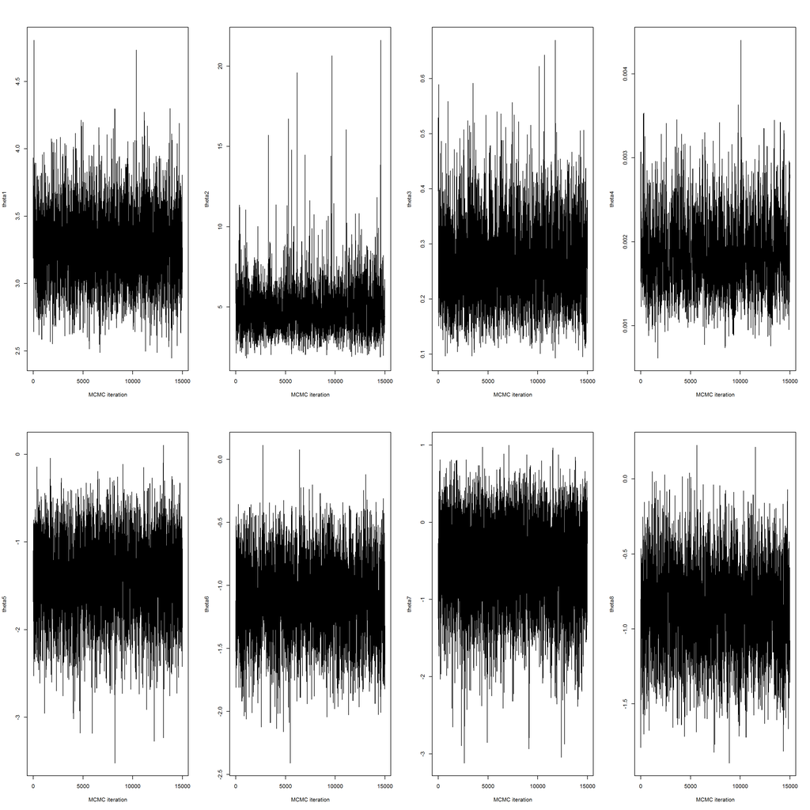

```r
chains <- do.call(cbind, model1[1:8]) %>%
  data.frame()

par(mfrow = c(2, 4))
# chain trace plots
for (i in 1:ncol(chains))
  plot(chains[, i], type = "l",
       ylab = paste("theta", i, sep = ""),
       xlab = 'MCMC iteration')
```

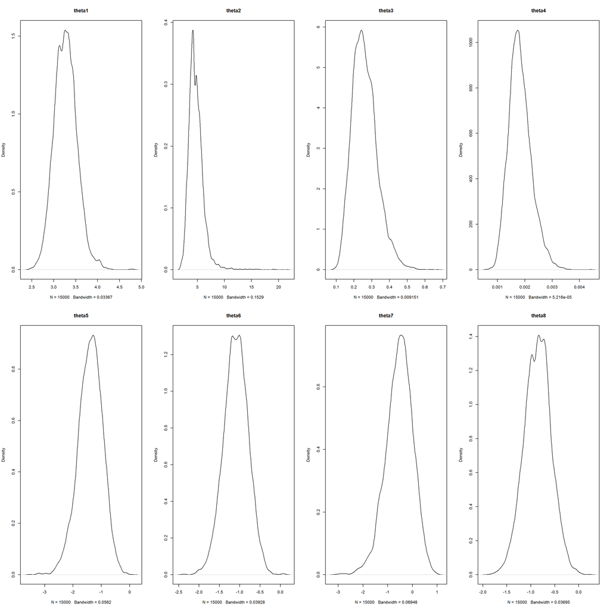

```r
# density plots
for (i in 1:ncol(chains))
  plot(density(chains[, i]),
       main = paste("theta", i, sep = ""))
```

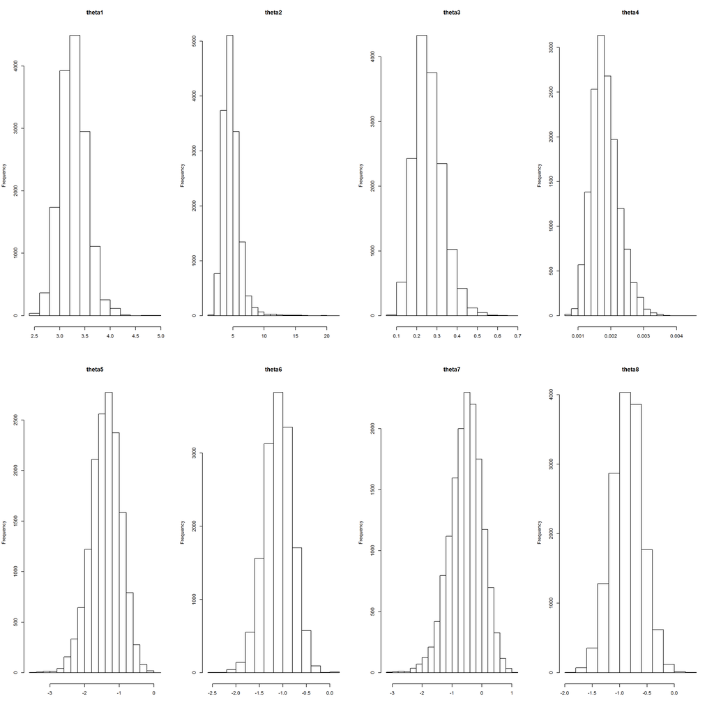

```r
# histograms
for (i in 1:ncol(chains))
  hist(chains[, i],
       main = paste("theta", i, sep = ""),
       xlab = '')
```

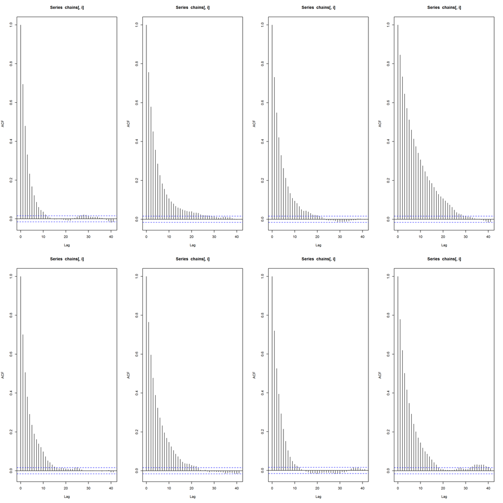

```r
# ACF plots
for (i in 1:ncol(chains)) acf(chains[, i])
```

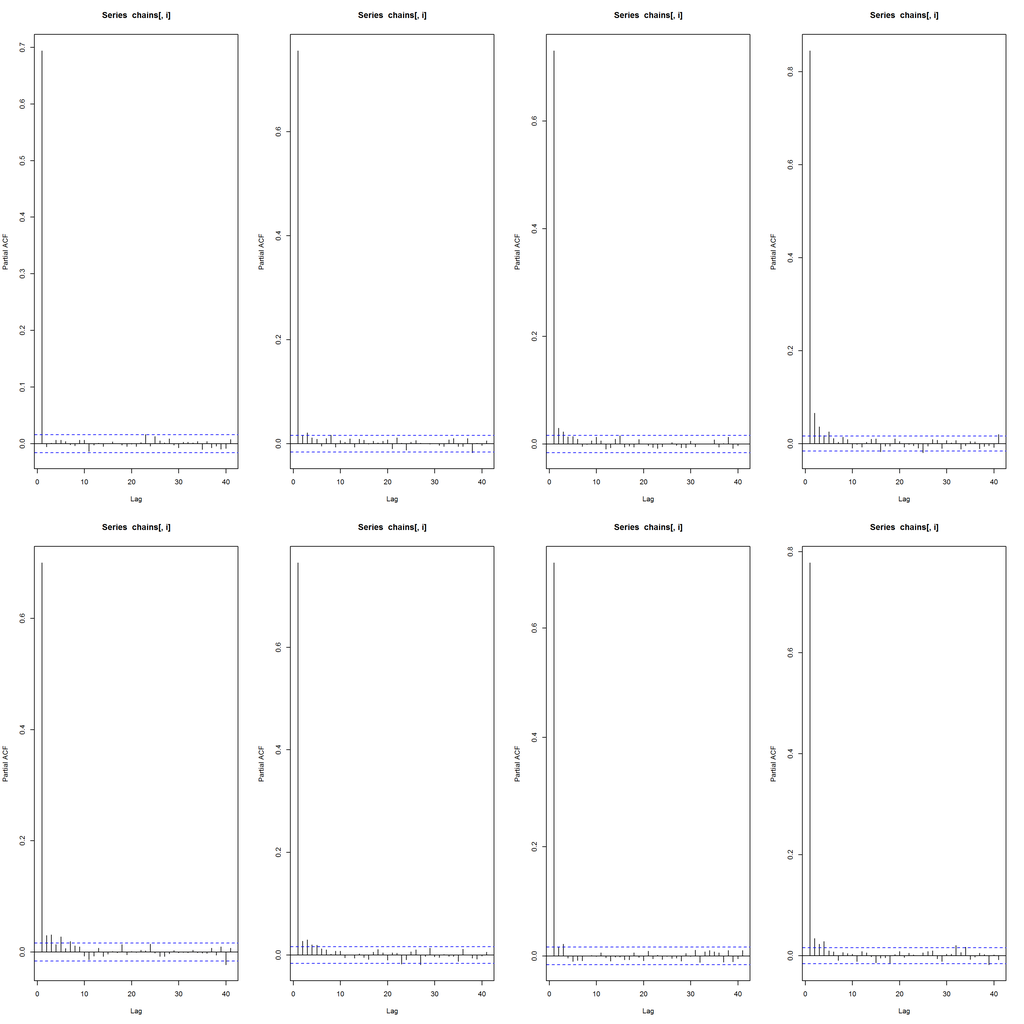

```r
# Partial ACF plots
for (i in 1:ncol(chains)) pacf(chains[, i])
```

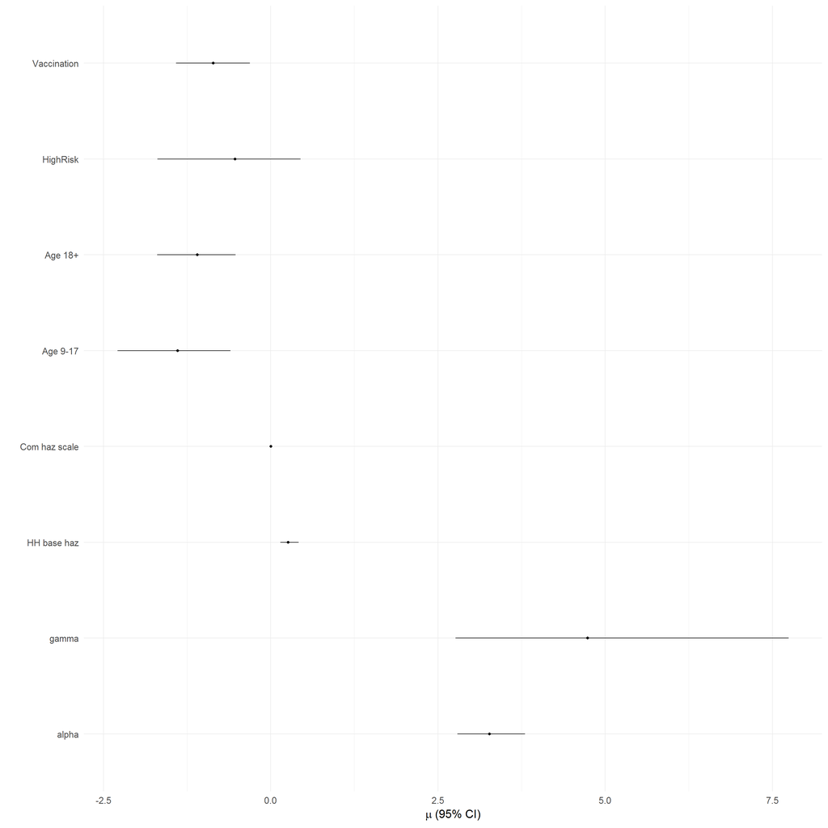

```r
# coefficient/hazard estimate plot with credible intervals
param.output %>%
  ggplot(aes(x = theta, y = mu)) %>%
  add(coord_flip()) %>%
  add(geom_point()) %>%
  add(geom_linerange(aes(ymin = LB, ymax = UB))) %>%
  add(theme_minimal(16)) %>%
  add(labs(
    y = expression(mu ~ '(95% CI)'),
    x = ""
  ))
```

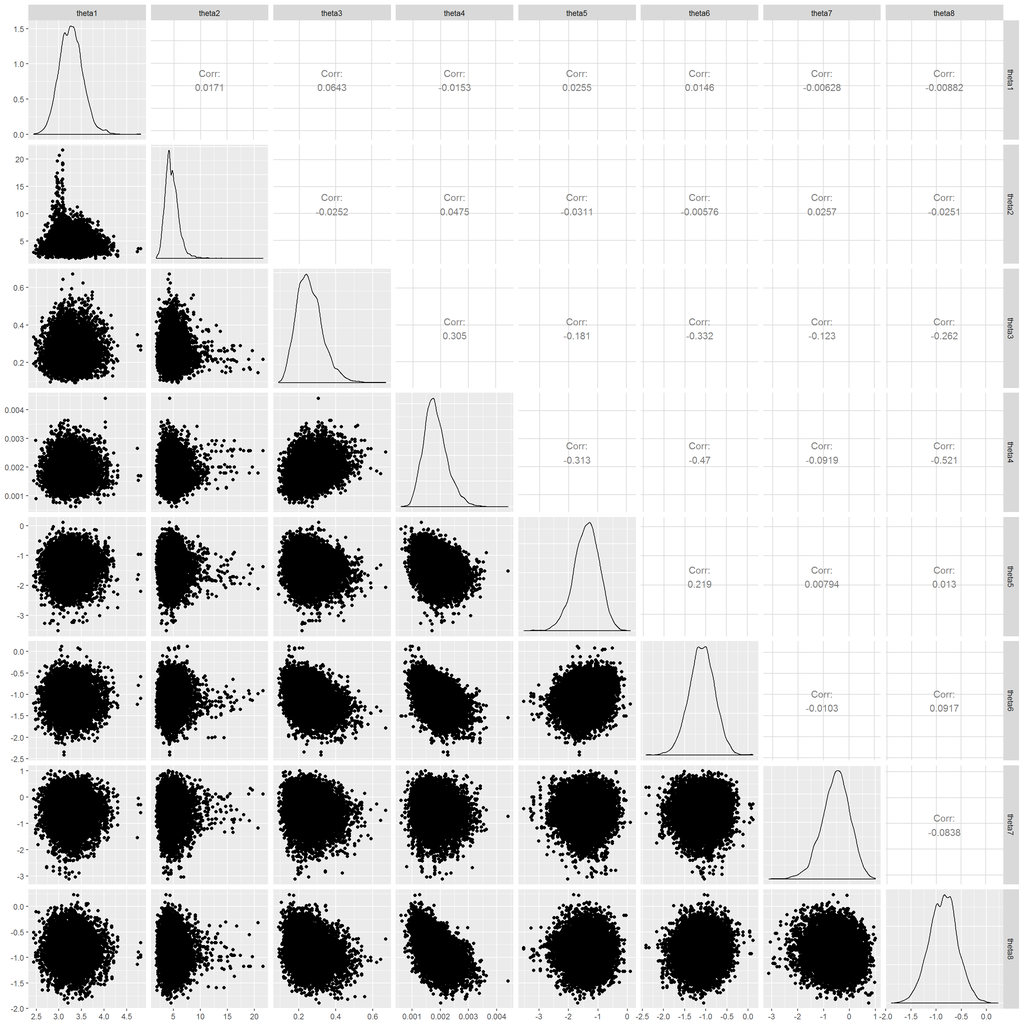

```r
GGally::ggpairs(chains)
```